# Chapter 3. Stationarity, white noise, and some basic time series models

### Weak stationarity and strict stationarity

A time series model which is both **mean stationary** and **covariance stationary** is called **weakly stationary**.

A time series model for which all joint distributions are invariant to shifts in time is called **strictly stationary**. For any collection of times $(t_1,t_2,...,t_K)$, the joint distribution of observations at these times should be the same as the joint distribution at $(t_1 + \tau,t_2 +\tau,...,t_K +\tau)$ for any $\tau$. If observations are equally spaced, for any collection of timepoints $n_1, ...n_K$ and for any lag $h$, the joint density function of $(Y_{n_1}, ... Y_{n_K})$ is the *same* as the joint density function $(Y_{n_1+h}, ... Y_{n_K+h})$.

Strict stationarity implies weak stationarity.

#### How could we assess whether a weak stationary model is appropriate for a time series dataset?

Plot the data and look visually for evidence of a trend as a violation of mean stationary. Compare variablility over different time intervals; covariance stationary implies constant variance.

#### How could we assess whether a strictly stationary model is appropriate for a time series dataset?

Not practical. We can check some moments look stable through time, which indicates weak stationary, but we can’t check all moments (even this is not enough).

Often there is a trend or some nonstationary behavior. But stationary models use fewer parameters and can be more practical. Thus we try to transform data to look stationary.

A seemingly non-stationary series may be a slice from a seemingly stationary series:

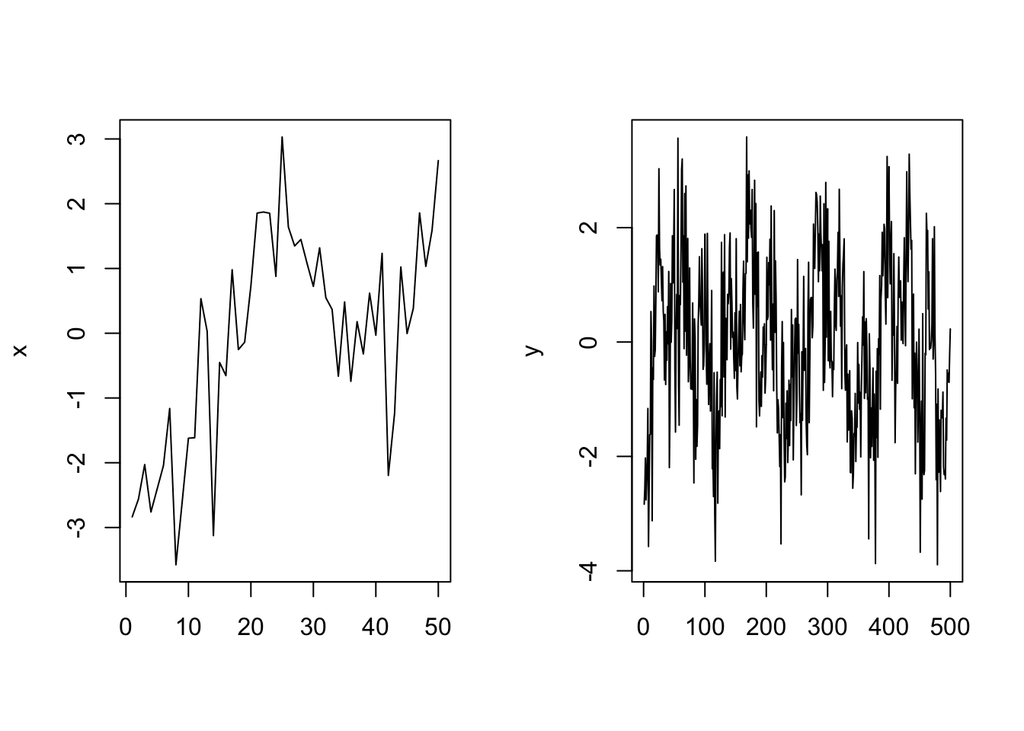

```r
N <- 500
times <- 1:N
T1 <- 120
T2 <- 37
set.seed(73413)
y <- sin(2*pi*(times/T1 + runif(1))) +   sin(2*pi*(times/T2 + runif(1))) + rnorm(N)
x <- y[1:50]
oldpars <- par(mfrow=c(1,2))
plot(x,ty="l",xlab="")
plot(y,ty="l",xlab="")
```

```r
par(oldpars)  # used to personalize the attrirbutes of plot()
```

### White noise

A time series model $\epsilon_{1:N}$ which is weakly stationary with
$$\begin{eqnarray} \nonumber
\mathbb E[\epsilon_n]&=& 0
\\
\nonumber
\operatorname{Cov}(\epsilon_m,\epsilon_n) &=& \left\{\begin{array}{ll}
\sigma^2, & \mbox{if $m=n$} \\
0, & \mbox{if $m\neq n$} \end{array}\right. ,
\end{eqnarray}$$
is said to be **white noise** with variance $\sigma^2$.

White noise in audio: produce static sound. Bcause it has a flat spectral density, with the same amplitude throughout the audible frequency range. All freqencies are equally represented.

#### Gaussian white noise

A sequence of independent identically distributed (IID) Normal random variables with mean zero and variance $\sigma^2$, $\epsilon_{1:N}\sim\operatorname{IID} N [0, \sigma^2]$.

#### Binary white noise

Let $\epsilon_{1:N}$ be IID with
$$\begin{eqnarray}
\nonumber
\epsilon_n = \left\{\begin{array}{ll}
1, & \mbox{with probability $1/2$} \\
-1, & \mbox{with probability $1/2$} \end{array}\right. .
\end{eqnarray}$$
$\mathbb E[\epsilon_n]=0$, $\operatorname{Var}(\epsilon_n)=1$ and $\operatorname{Cov}(\epsilon_m,\epsilon_n)=0$ for $m\neq n$. Therefore, $\epsilon_{1:N}$ is white noise.

For any $p\in (0,1)$, we could have
$$\begin{eqnarray}
\nonumber
\epsilon_n = \left\{\begin{array}{ll}
(1-p)/p, & \mbox{with probability $p$} \\
-1, & \mbox{with probability $1-p$} \end{array}\right. .
\end{eqnarray}$$

#### Sinusoidal white noise

Let $\epsilon_n = \sin(2\pi n U)$, with a single draw $U\sim\mathrm{Uniform}[0,1]$ determining the time series model for all $n\in 1:N$.

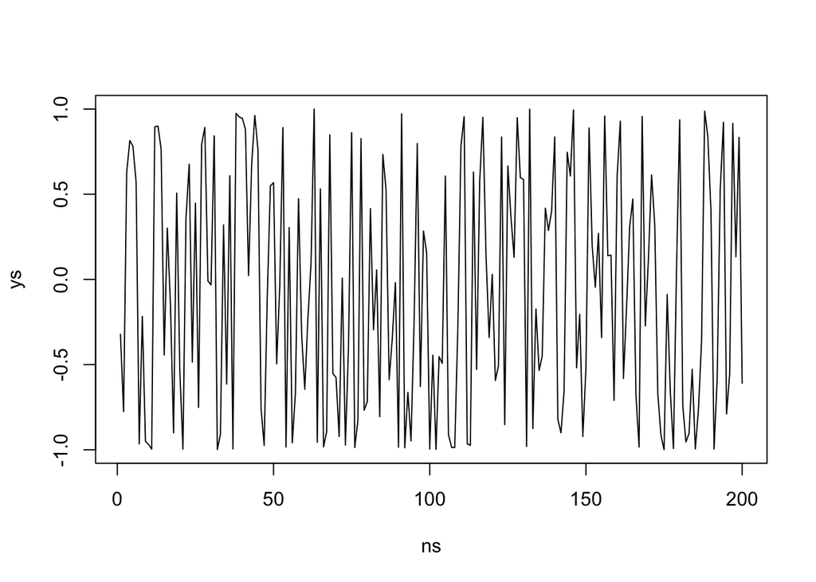

```r
ns = 1:200
us = runif(ns, min = 0, max = 1)
ys = sin(2*pi*ns*us)
plot(ns, ys, type="l")
```

**Question**: Show that $\epsilon_{1:N}$ is weakly stationary and is white noise, but NOT strictly stationary:

A counter example: e.g., $\mathbb P[\epsilon_2=0 \text{ given } \epsilon_1=1]=1$, whereas $\mathbb P[\epsilon_3=0 \text{ given }\epsilon_2=1]=0$

### The AR($p$) autoregressive model

The order $p$ autoregressive model, abbreviated to AR($p$), is
$$\quad\quad \quad Y_n = \phi_1 Y_{n-1}+\phi_2Y_{n-2}+\dots+\phi_pY_{n-p} + \epsilon_n$$
If $\{\epsilon_n\}$ is a Gaussian white noise process, it is called the Gaussian AR(p) model.

This is a **stochastic difference equation**. It is a difference equation (also known as a recurrence relation) since each time point is specified recursively in terms of previous time points.

To complete the model, we need to **initialize** the solution to the stochastic difference equation. Supposing we want to specify a distribution for $Y_{1:N}$, we have some choices in how to set up the initial values:

- We can specify $Y_{1:p}$ explicitly, to get the recursion started.
- We can specify $Y_{1-p:0}$ explicitly. ($1-p$ here means a sequence before $Y_{1:p}$ which is *cut* after $Y_{1:p}$ generated.)
- For either of these choices, we can define these initial values either to be additional parameters in the model (i.e., not random) or to be specified random variables.
- **Common practice**: if we want our model to be strictly stationary, we must initialize so that $Y_{1:p}$ have the proper joint distribution for this stationary model.

For example, define $M2: Y_n = 0.6 Y_{n-1}+ \epsilon_n$, where $\{\epsilon_n\}\sim \operatorname{IID}N[0, 1]$.

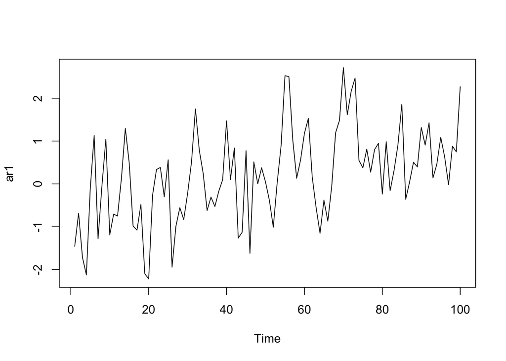

```r
set.seed(123456789)
ar1 <- arima.sim(list(ar=0.6),n=100,sd=1)
# ar -- indicates the coefficient for auto-regressive part
# n  -- length of output series before un-differencing. Strictly positive.
plot(ar1,type="l")
```

`sd` is the standard deviation of `rand.gen`, default by `rnorm`.

Another way is to generate the series directly:

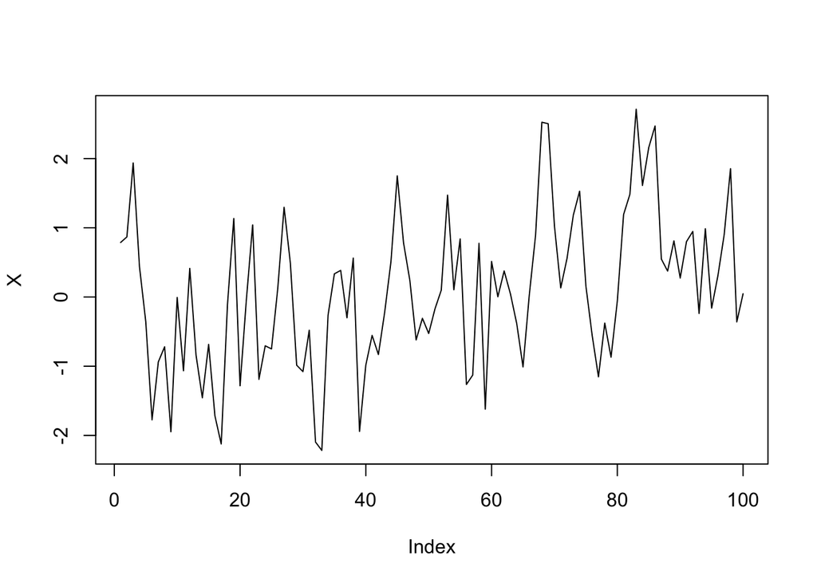

```r
set.seed(123456789)
N <- 100
X <- numeric(N)
X[1] <- rnorm(1,sd=1.56)
for(n in 2:N) X[n] <- 0.6 * X[n-1] + rnorm(1)
plot(X,type="l")
```

This looks similar to the arima.sim simulation, except near the start. This is because `arima.sim` use innovations for the burn-in period of the time series. Burn-in is a colloquial term that describes the practice of throwing away some iterations at the beginning of an MCMC run. `rnorm` is the default function used to generate the innovations.

**Question**: compute the autcovariance function for model M2.
$$\begin{aligned}
Y_n &= 0.6Y_{n-1} + \epsilon_n \\
&= 0.6(0.6Y_{n-2} + \epsilon_{n-1}) + \epsilon_n \\
&= ...
\end{aligned}$$
In the stationary case, $Y_n = \sum_{k=0}^{\infty}(0.6)^k\epsilon_{n-k}$. By stationary, we can talk about the distribution at negative values of $n$.
$$\begin{aligned}
\mathcal Y_h &= \operatorname{Cov}\left(\sum_{l=0}^{\infty}0.6^l\epsilon_{n+h-l}, \sum_{k=0}^{\infty}0.6^k\epsilon_{n-k}\right) \\
&= \sum_{k=0}^{\infty}\sum_{l=0}^{\infty}0.6^{l+k}\operatorname{Cov}\left(\epsilon_{n+h-l},\epsilon_{n-k}\right)
\end{aligned}$$
Since $\epsilon$ is white noise, the covariance is **nonzero only when $l-h = k$**, where the covaraince (variance, actually) is $1$. Therefore,
$$\begin{aligned}
\mathcal Y_h &= \sum_{k=0}^{\infty}0.6^{h+2k} \\
&= \frac{0.6^h}{1-0.6^2} \\
&= 0.6^h \times 1.56, \qquad h>0
\end{aligned}$$

### The MA($q$) moving average model

The order q moving average model, abbreviated to MA($q$), is
$$Y_n = \epsilon_n +\theta_1 \epsilon_{n-1} +\dots+\theta_q\epsilon_{n-q}$$
where $\epsilon$ is a white noise process.

To fully specify $Y_{1:N}$ we must specify the joint distribution of $\epsilon_{1-q:N}$. Often, we consider the **Gaussian MA(q)** model, where $\{\epsilon_n\}$ is a Gaussian white noise process.

For example, define $M4: Y_n = \epsilon_n + 1.5\epsilon_{n-1}+\epsilon_{n-2}$, where $\epsilon_n\sim \operatorname{IID} N[0,1]$.

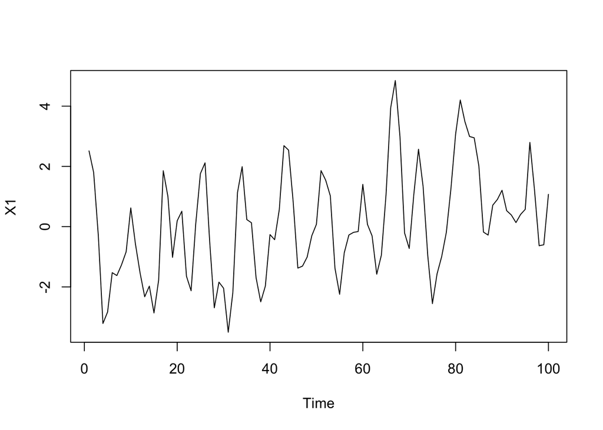

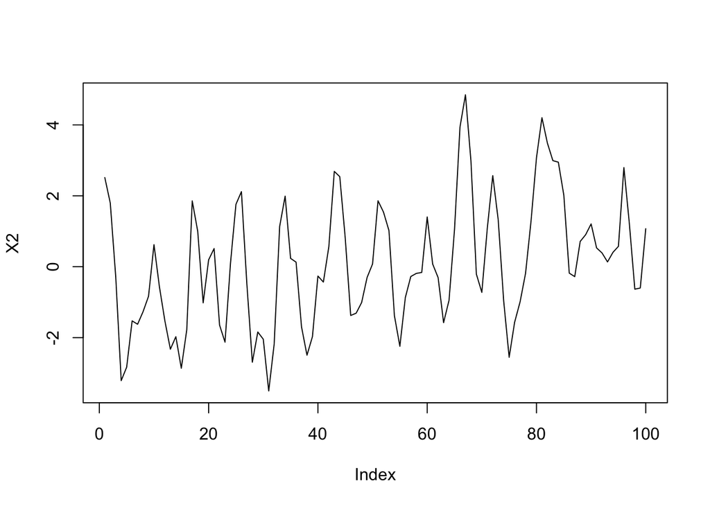

```r
N <- 100
set.seed(123456789)
X1 <- arima.sim(list(ma=c(1.5,1)),n=N,sd=1)
set.seed(123456789)
epsilon <- rnorm(N+2)
X2 <- numeric(N)  # create an arra of length N, each is 0
for(n in 1:N) X2[n] <- epsilon[n+2]+1.5*epsilon[n+1]+epsilon[n]
plot(X1,type="l") ; plot(X2,type="l")
```

We can check that $X1$ and $X2$ are identical:

```r
all(X1==X2)
```

```
## [1] TRUE
```

### The random walk model

The random walk model is
$$Y_n = Y_{n-1} + \epsilon_n$$
where $\{\epsilon_n\}$ is white noise. Unless otherwise specified, we usually initialize with $Y_0=0$. If $\{\epsilon_n\}$ is Gaussian white noise, then we have a Gaussian random walk. The random walk model is a special case of AR(1) with $\phi_1=1$. This **stochastic difference equation** has an exact solution
$$Y_n = \sum_{k=1}^n\epsilon_k$$
We can also call $Y_{0:N}$ an **integrated white noise process**. If data ${y_{1:N}}$ are *modeled as* a random walk, the value of $Y_0$ is usually an unknown. Rather than introducing an unknown parameter to our model, we may initialize our model at time $t_1$ with $Y_1={y_1}$.

#### Random walk model with drift

The random walk with drift model is defined by
$$Y_n = Y_{n-1} + \mu + \epsilon_n,$$
driven by a white noise process $\{\epsilon_n\}$. It has solution
$$Y_n = Y_0 + n\mu + \sum_{k=1}^n\epsilon_k.$$
Here, $\mu$ is the mean of increments, NOT of the random walk process itself. For this model, we **must** define $Y_0$ to initialize the model and complete the model specification. Unless otherwise specified, we usually initialize with $Y_0=0$.

**Questoin**: compute the mean and covariance functions for the random walk model with and without drift.

For random walk with drift, if $Y_0 = y_0$,
$$\mu_Y(n) = n\mu + y_0$$

### Example: modeling financial markets as a random walk

It is suggested that the logarithm of a stock market index (or, for that matter, the value of an individual stock or other investment) might behave like a random walk with drift. We can test this on an example dataset:

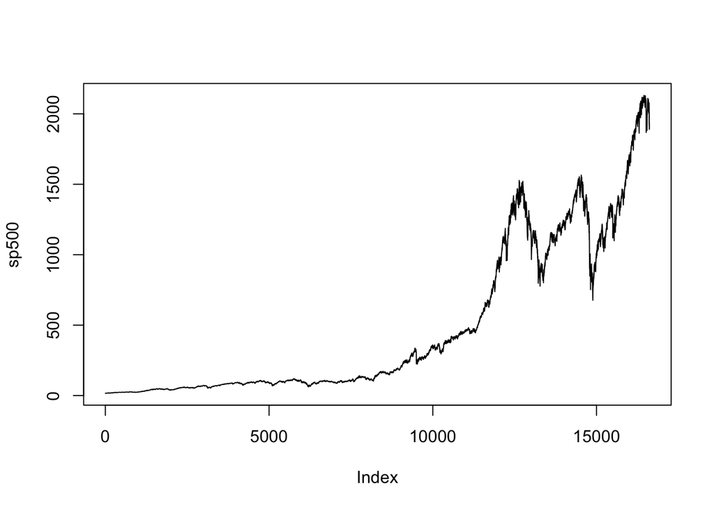

```r
dat <- read.table("data/sp500.csv",sep=",",header=TRUE)
N <- nrow(dat)
sp500 <- dat$Close[N:1] # data are in reverse order in sp500.csv par(mfrow=c(1,2))
plot(sp500,type="l")
```

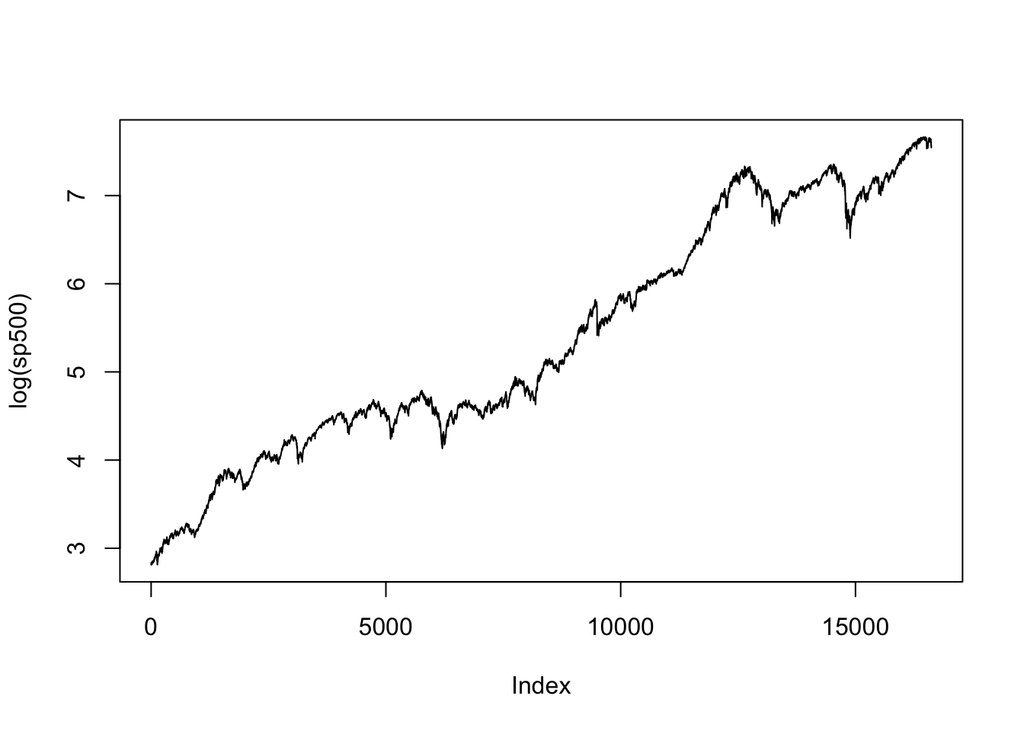

```r
plot(log(sp500),type="l")
```

We can compare the data with simulations from a fitted model. A simple starting point is a Gaussian random walk with drift with parameters estimated from the data:

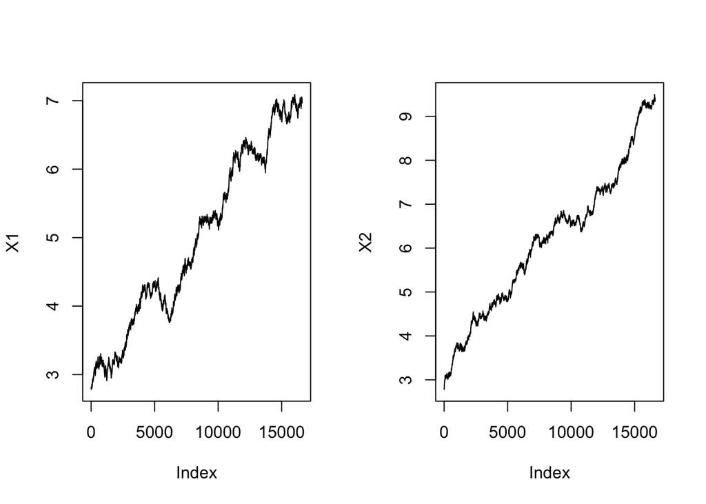

```r
mu <- mean(diff(log(sp500)))
sigma <- sd(diff(log(sp500)))
set.seed(95483123)
X1 <- log(sp500[1])+cumsum(c(0,rnorm(N-1,mean=mu,sd=sigma)))
# cumsum() is cumulated sum of array c()
# c() is of length N, 0 and N-1 from rnorm()
set.seed(324324587)
X2 <- log(sp500[1])+cumsum(c(0,rnorm(N-1,mean=mu,sd=sigma)))
par(mfrow=c(1,2))
plot(X1,type="l") ; plot(X2,type="l")
```

```r
par(mai=c(0.8,0.5,0.1,0.1))
```

It seems reasonable so far. Next, plot the autocorrelation function of `diff(log(sp500))`:

It is bad style to refer to quantities using computer code notation. We should set up mathematical notation in the text. In a MIDTERM project, it is better to code as follow:

Let $z_n = \log y_n - \log y_{n-1}$. The temporal difference of the log of the value of an investment is called the return on the investment. Plot $z_{2:N}$,

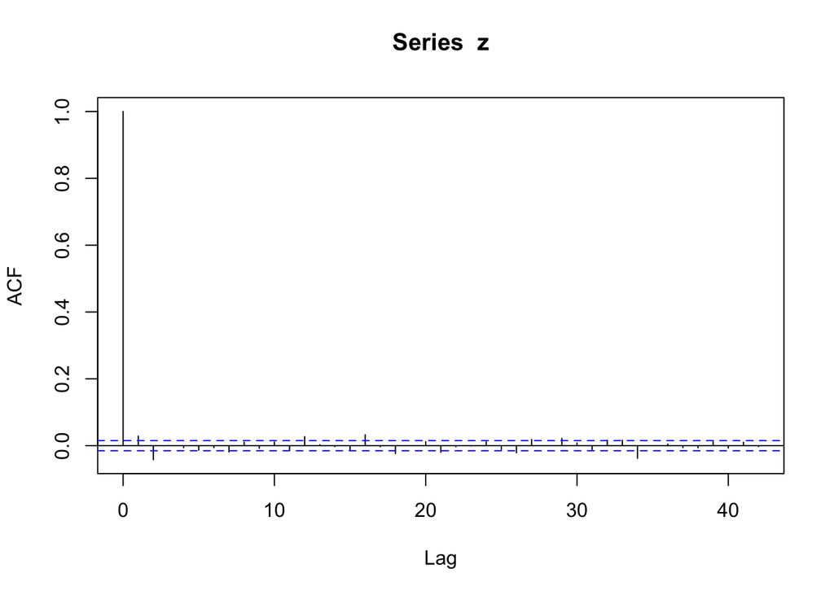

```r
# acf(diff(log(sp500)))  $ DON'T do this
z <- diff(log(sp500))
acf(z)
```

The length of the time series is relevant when considering **practical versus statistical significance**. For small datasets, small effects of no practical significance will also usually be statically insiginificant.

It seems the S&P 500 returns (centered, by subtracting the sample mean) may be a real-life time series well modeled by white noise. However, things become less clear when we look at the **absolute value of the centered returns**:

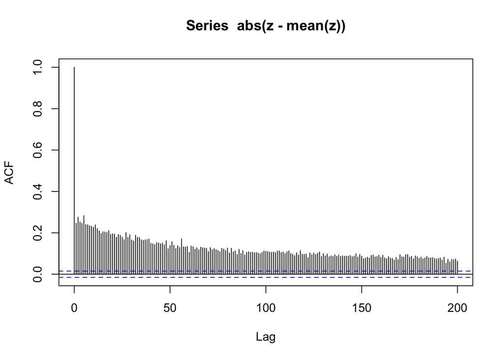

```r
acf(abs(z-mean(z)),lag.max=200)
```

It seems the magnitues are correlated, though actual values are not. This contradicts independent white noise as a model. It doesn’t contradict a weak white noise assumption of uncorellation at lags $h>0$.